# Introducción a modelos lineales

- Mostrar todo el código
- Ocultar todo el código
- Ver el código fuente

Autor/a

Filip Andras — CIMCYC, Universidad de Granada

Fecha de publicación

12 noviembre 2026

Resumen

Qué es un modelo lineal: intercepto, pendiente y error, con un widget para buscar los parámetros a mano. Dos ejemplos de Winter: el tono de voz en función del sexo (cómo codifica R una variable categórica) y de la edad (centrar el predictor), y la notación para más de un predictor (efectos principales e interacciones). Por último, los supuestos del modelo lineal, uno a uno, y cómo comprobarlos con `performance::check_model()`.

Este documento sigue el primer tutorial de Winter (2013), *Linear models and linear mixed effects models in R with linguistic applications* (arXiv:1308.5499).

# La idea en una ecuación

Un modelo lineal dice que la variable que queremos explicar es una recta más un error:

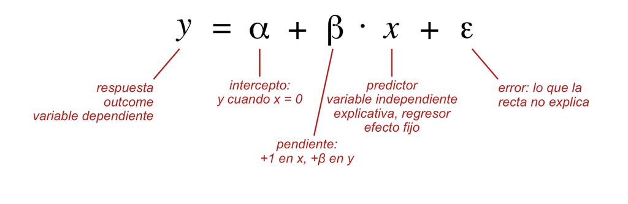

Cómo se leen las letras griegas:

- $\alpha$: alfa
- $\beta$: beta
- $\varepsilon$: épsilon
- $\sigma$: sigma

**Nota**

A veces $\alpha$ se escribe $\beta_0$ (“beta cero”) y $\beta$ se escribe $\beta_1$ (“beta uno”):

$$y = \beta_0 + \beta_1 \cdot x + \varepsilon$$

En R el mismo modelo se escribe así:

`y ~ x`

La virgulilla se lee “en función de”, y R añade por su cuenta $\alpha$ y $\varepsilon$.

**Ejemplo:**

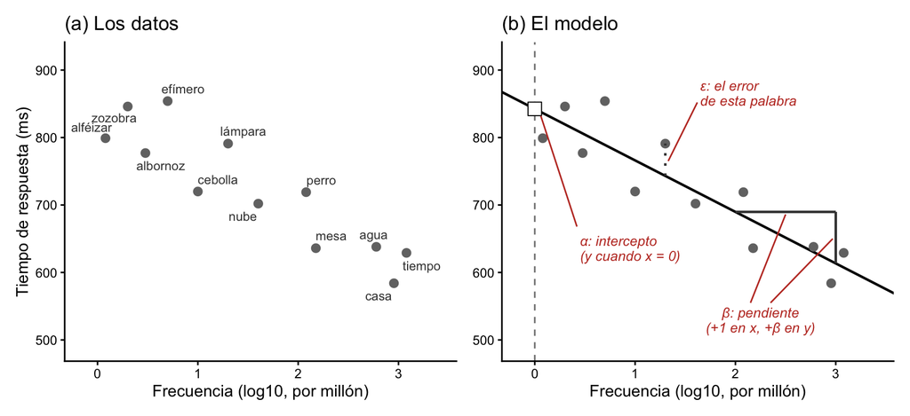

Doce palabras, su frecuencia de uso ($x$, en logaritmo) y el tiempo que se tarda en reconocerlas ($y$). Datos inventados.

En (a), los datos. En (b), la recta de `lm()`: el cuadrado blanco es $\alpha$, el escalón es $\beta$ y la línea punteada es el $\varepsilon$ de una palabra.

Las palabras frecuentes se reconocen antes: la pendiente es negativa.

### Pruébalo: busca los parámetros

α (intercepto):  
β (pendiente):

Suma de cuadrados de los residuos:

Las mismas doce palabras, con una recta plana para empezar.

**$\alpha$** sube y baja la recta. **$\beta$** la inclina.

Mira los residuos (líneas punteadas) y sus cuadrados: cada área es un residuo al cuadrado. `lm()` elige la recta con la menor suma de áreas; el botón te lleva a ella.

La misma figura girada: la recta es ahora la horizontal en cero y cada residuo cuelga de ella. A la derecha, tumbada, la campana normal ajustada a los residuos de la recta actual: su centro es la media de los residuos, (la línea gris discontinua), y su anchura es $\sigma$ = (la línea roja, del centro al punto de inflexión). Con un intercepto malo la campana se desplaza; con una pendiente mala se ensancha. Con la recta de `lm()` queda centrada en la recta y es la más estrecha posible: eso es lo que el modelo asume de los errores.

Eso es lo que falta en la ecuación de arriba: de dónde vienen los errores. El modelo asume que **son normales**, con media cero y una única desviación típica $\sigma$, e **independientes** entre sí:

$$\varepsilon_i \overset{\text{iid}}{\sim} \mathcal{N}(0, \sigma^2)$$

*iid*: **independientes e idénticamente distribuidos**. Cada $\varepsilon_i$, el error de la palabra $i$, sale de la misma normal, con la misma $\sigma$, y no depende de los errores de las demás palabras.

# Más ejemplos: Winter (2013)

## Tono de voz en función del sexo

> Imagina que no sabes nada sobre hombres y mujeres y quieres saber si su tono de voz es distinto y, si lo es, cuánto. Pides a unas cuantas personas que digan una palabra y mides su tono. En los datos de abajo, las mujeres parecen unos 100 Hz más agudas. Pero puede que hayas tenido mala suerte con la muestra. El modelo lineal da una estimación precisa de la diferencia y de la probabilidad de verla solo por azar.

> Resumido de Winter (2013, pp. 1-2).

[figure not shown]

Winter lo escribe así:

`pitch ~ sex + ε`

El tono “en función de” el sexo, más ruido. Aquí el predictor no es un número sino una categoría con dos niveles, `female` y `male`. En la figura del margen, cada grupo es una columna de puntos, el guion gris es su media y la recta une las dos medias. La “línea más ruido” sigue siendo la misma idea: la recta es el modelo, y el ruido es lo que cada persona se aparta de la media de su grupo.

Seis datos inventados por Winter: el tono de voz (Hz) de tres mujeres y tres hombres.

```r
pitch_sex <- tibble(
  sex   = c(rep("female", 3), rep("male", 3)),
  pitch = c(233, 204, 242, 130, 112, 142)
)
print(pitch_sex)
```

```
# A tibble: 6 × 2
  sex    pitch
  <chr>  <dbl>
1 female   233
2 female   204
3 female   242
4 male     130
5 male     112
6 male     142
```

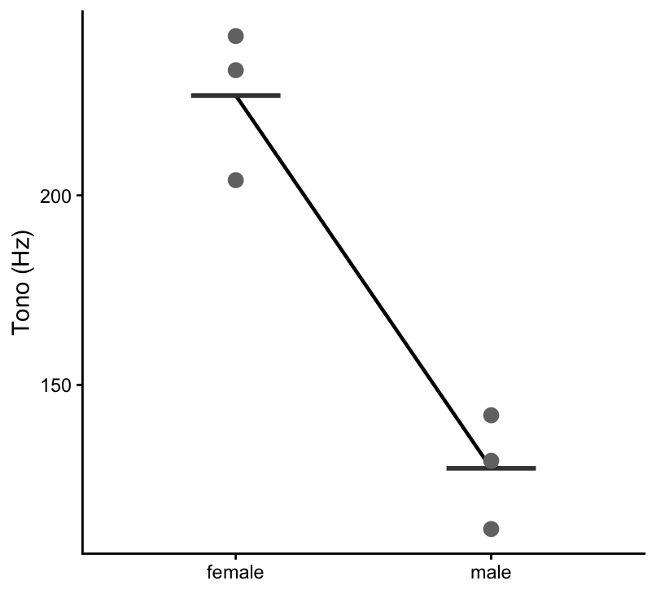

```r
model_sex <- lm(formula = pitch ~ sex, data = pitch_sex)
summary(model_sex)
```

```
Call:
lm(formula = pitch ~ sex, data = pitch_sex)

Residuals:
      1       2       3       4       5       6
  6.667 -22.333  15.667   2.000 -16.000  14.000

Coefficients:
            Estimate Std. Error t value  Pr(>|t|)
(Intercept)   226.33      10.18  22.224 0.0000243 ***
sexmale       -98.33      14.40  -6.827   0.00241 **
---
Signif. codes:  0 '***' 0.001 '**' 0.01 '*' 0.05 '.' 0.1 ' ' 1

Residual standard error: 17.64 on 4 degrees of freedom
Multiple R-squared:  0.921, Adjusted R-squared:  0.9012
F-statistic: 46.61 on 1 and 4 DF,  p-value: 0.002407
```

Qué mirar en la salida:

- `(Intercept)` es la media del grupo de referencia. R toma como referencia el primer nivel por orden alfabético, `female`.
- `sexmale` es la diferencia entre la media de `male` y la de `female`. La media de los hombres es el intercepto más ese coeficiente. Su p-valor contrasta si esa diferencia es cero.
- `Multiple R-squared` es la proporción de varianza del tono explicada por el sexo.
- La F del final contrasta el modelo completo contra el modelo sin predictores. Con un solo predictor, su p-valor coincide con el del coeficiente.

La salida, en la ecuación:

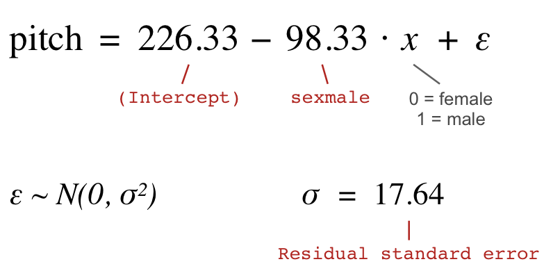

El modelo con los números que ha estimado `lm()` (intercepto 226.3, pendiente -98.3):

$$\text{Pitch}_{\text{mujeres}} = 226.3 + (-98.3) \cdot 0 = 226.3$$

$$\text{Pitch}_{\text{hombres}} = 226.3 + (-98.3) \cdot 1 = 128$$

Comprobación de las dos medias:

```r
# La media del tono en cada grupo: agrupar por sexo y resumir
pitch_means <- pitch_sex |>
  group_by(sex) |>
  summarise(mean_pitch = mean(pitch))
pitch_means
```

```
# A tibble: 2 × 2
  sex    mean_pitch
  <chr>       <dbl>
1 female     226.33
2 male       128
```

### Por qué 0 = mujer y 1 = hombre

Para dibujar una recta, R necesita que el sexo sea un número. Convierte la variable en un factor y ordena sus niveles alfabéticamente. El primer nivel, `female`, pasa a ser el 0, la referencia. El segundo, `male`, es el 1. El intercepto es el valor de la recta en x = 0, así que es la media de las mujeres.

**El orden por defecto: `female` = 0.**

```r
# factor() ordena los niveles alfabeticamente;
# el primero es la referencia (el 0)
pitch_sex <- pitch_sex |>
  mutate(sex = factor(sex))
levels(pitch_sex$sex)
```

```
[1] "female" "male"
```

```r
model_female_ref <- lm(formula = pitch ~ sex, data = pitch_sex)
coef(model_female_ref)
```

```
(Intercept)     sexmale
  226.33333   -98.33333
```

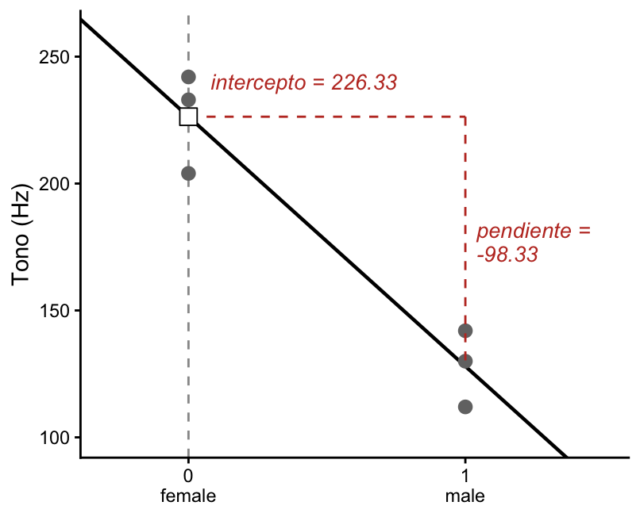

Es el mismo modelo de antes. `(Intercept)` es la media de las mujeres y `sexmale` es lo que cambia el tono al pasar de 0 a 1.

**Cambiar la referencia: `male` = 0.**

```r
# levels = fija el orden de los niveles: male primero, asi male es el 0
pitch_sex <- pitch_sex |>
  mutate(sex = factor(sex, levels = c("male", "female")))
levels(pitch_sex$sex)
```

```
[1] "male"   "female"
```

```r
model_male_ref <- lm(formula = pitch ~ sex, data = pitch_sex)
coef(model_male_ref)
```

```
(Intercept)   sexfemale
  128.00000    98.33333
```

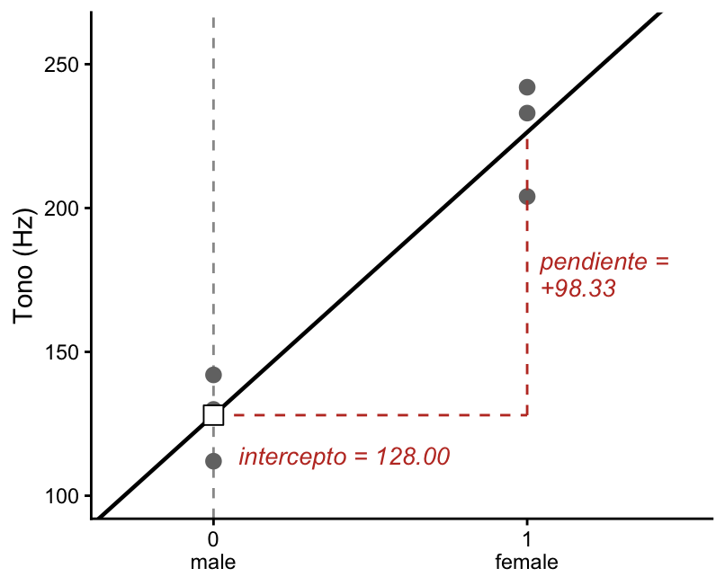

Ahora `(Intercept)` es la media de los hombres. La pendiente, `sexfemale`, es la misma distancia que antes con el signo cambiado.

**Nota**

Este esquema, con un grupo de referencia en el 0 y el otro en el 1, es lo que se llama *treatment coding*.

**Otros tipos de contrastes: -0.5 y +0.5.**

```r
# deviation coding: cada grupo a media unidad del 0
pitch_sex <- pitch_sex |>
  mutate(sex_dev = if_else(sex == "female", -0.5, 0.5))

model_sex_dev <- lm(formula = pitch ~ sex_dev, data = pitch_sex)
coef(model_sex_dev)
```

```
(Intercept)     sex_dev
  177.16667   -98.33333
```

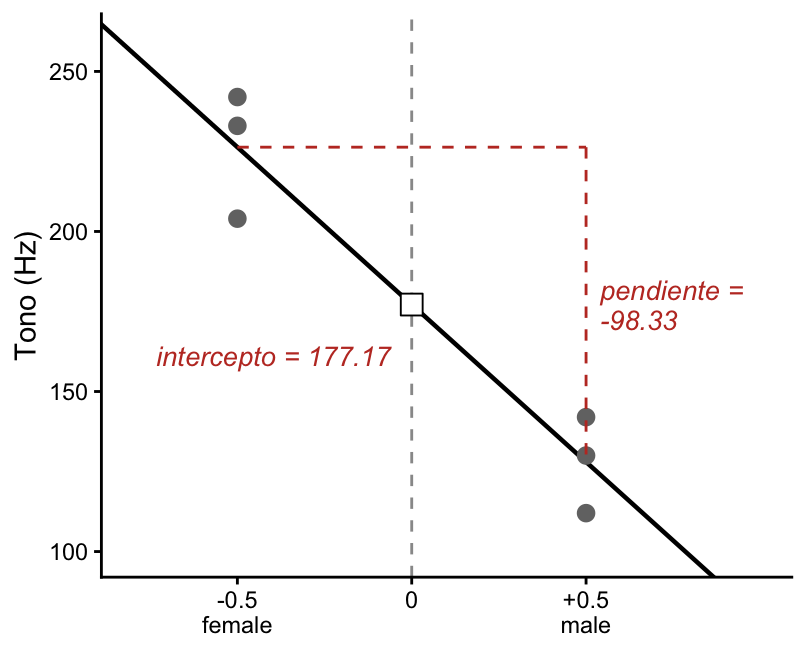

El 0 queda en medio de los dos grupos, y `(Intercept)` es la media de las dos medias. La pendiente es la misma que con `female` = 0, porque la distancia entre los grupos sigue siendo 1. Esta es la codificación que usaremos en el curso.

**NotaLesson learned**

La codificación decide dónde está el 0, y el intercepto es siempre el valor de la recta en ese 0. Por eso cambia de una codificación a otra: media de las mujeres, media de los hombres, media de las dos medias. El tamaño de la diferencia entre los grupos es el mismo en las tres codificaciones, y las predicciones del modelo también.

### Cómo redactarlo

> Ajustamos un modelo lineal con el tono de voz (Hz) como variable dependiente y el sexo como predictor (referencia: mujeres). El modelo fue significativo, *F*(1, 4) = 46.61, *p* = .002, y explicó el 92 % de la varianza del tono (*R*² = .92, *R*² ajustado = .90; error típico residual = 17.6 Hz). El tono medio de las mujeres fue de 226.3 Hz (EE = 10.2). Los hombres tuvieron un tono 98.3 Hz más grave (*b* = −98.33, EE = 14.40, *t*(4) = −6.83, *p* = .002), es decir, 128.0 Hz de media.

## Tono de voz en función de la edad

Winter lo escribe así:

`pitch ~ age + ε`

Ahora el predictor es un número, la edad en años. En la figura del margen, cada punto es una persona y la recta es el modelo.

Otros seis datos inventados: el tono de voz de seis personas de distinta edad.

```r
pitch_age <- tibble(
  age   = c(14, 23, 35, 48, 52, 67),
  pitch = c(252, 244, 240, 233, 212, 204)
)
print(pitch_age)
```

```
# A tibble: 6 × 2
    age pitch
  <dbl> <dbl>
1    14   252
2    23   244
3    35   240
4    48   233
5    52   212
6    67   204
```

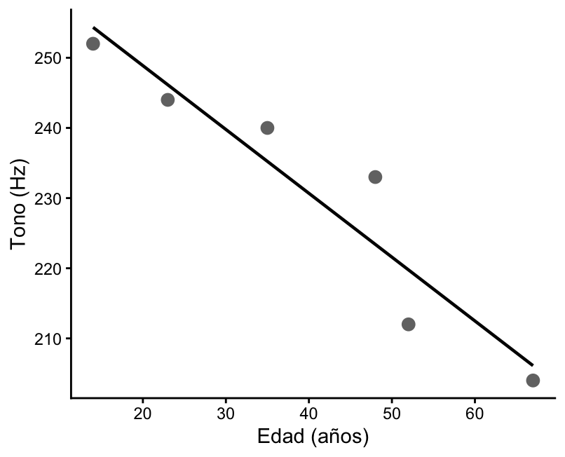

Mismo modelo, ahora con un predictor continuo: la “línea” es una recta.

```r
model_age <- lm(formula = pitch ~ age, data = pitch_age)
summary(model_age)
```

```
Call:
lm(formula = pitch ~ age, data = pitch_age)

Residuals:
     1      2      3      4      5      6
-2.338 -2.149  4.769  9.597 -7.763 -2.115

Coefficients:
            Estimate Std. Error t value   Pr(>|t|)
(Intercept) 267.0765     6.8522   38.98 0.00000259 ***
age          -0.9099     0.1569   -5.80    0.00439 **
---
Signif. codes:  0 '***' 0.001 '**' 0.01 '*' 0.05 '.' 0.1 ' ' 1

Residual standard error: 6.886 on 4 degrees of freedom
Multiple R-squared:  0.8937,    Adjusted R-squared:  0.8672
F-statistic: 33.64 on 1 and 4 DF,  p-value: 0.004395
```

Qué mirar en la salida:

- `(Intercept)` es el tono predicho a los 0 años. No tiene sentido: nadie tiene 0 años en la muestra. Es un valor matemáticamente correcto pero ininterpretable.
- `age` es el cambio en el tono (Hz) por cada año más de edad, la pendiente.

La salida, en la ecuación:

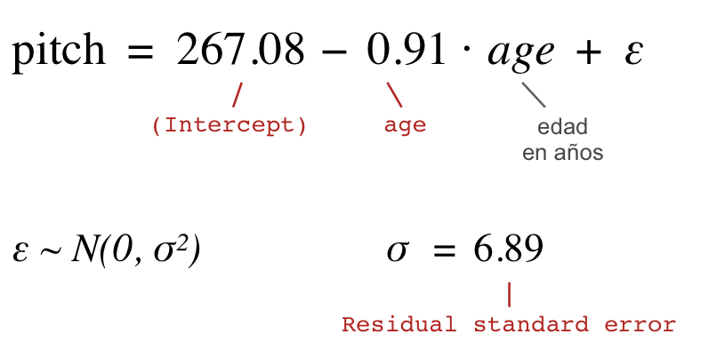

El modelo con los números que ha estimado `lm()` (intercepto 267.1, pendiente -0.91):

$$\text{Pitch}_{\text{0 años}} = 267.1 + (-0.91) \cdot 0 = 267.1$$

$$\text{Pitch}_{\text{14 años}} = 267.1 + (-0.91) \cdot 14 = 254.3$$

## Centrar el predictor

**La edad en años: x = 0 es la edad 0.**

```r
coef(model_age)
```

```
(Intercept)         age
267.0764640  -0.9098694
```

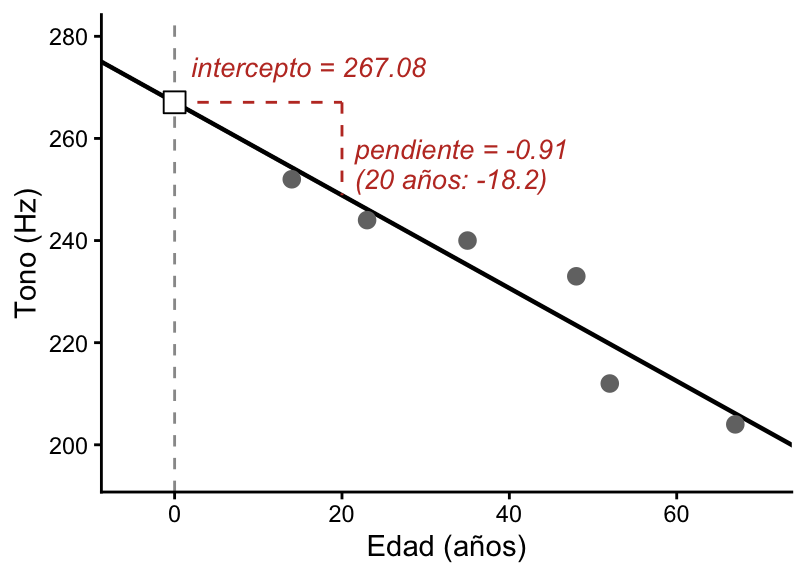

El intercepto es el valor de la recta en x = 0. Con la edad en años, x = 0 es la edad 0, lejos de los datos.

**Centrar: x = 0 es la edad media.**

Restando la media a la edad, el intercepto pasa a ser el tono predicho para una persona de edad media. La pendiente y su p-valor no cambian.

```r
pitch_age <- pitch_age |>
  mutate(age_c = age - mean(age))

model_age_c <- lm(formula = pitch ~ age_c, data = pitch_age)
summary(model_age_c)
```

```
Call:
lm(formula = pitch ~ age_c, data = pitch_age)

Residuals:
     1      2      3      4      5      6
-2.338 -2.149  4.769  9.597 -7.763 -2.115

Coefficients:
            Estimate Std. Error t value    Pr(>|t|)
(Intercept) 230.8333     2.8113   82.11 0.000000132 ***
age_c        -0.9099     0.1569   -5.80     0.00439 **
---
Signif. codes:  0 '***' 0.001 '**' 0.01 '*' 0.05 '.' 0.1 ' ' 1

Residual standard error: 6.886 on 4 degrees of freedom
Multiple R-squared:  0.8937,    Adjusted R-squared:  0.8672
F-statistic: 33.64 on 1 and 4 DF,  p-value: 0.004395
```

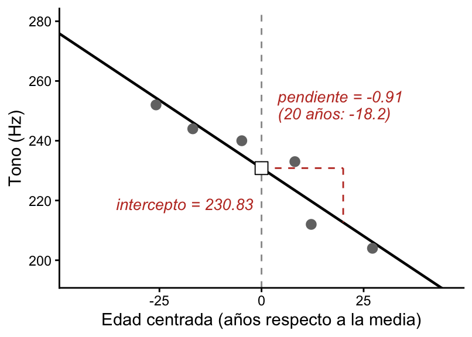

**NotaLesson learned**

Centrar no cambia la recta ni la pendiente: solo mueve el 0 del eje x. Con la edad en años, el intercepto es el tono a los 0 años, fuera de los datos. Con la edad centrada, es el tono a la edad media, en mitad de los datos.

## Más de un predictor: efectos principales e interacciones

Los dos predictores en el mismo modelo. Cada uno tiene su propia pendiente, su **efecto principal** (*main effect*): el efecto del sexo controlando la edad, y el de la edad controlando el sexo.

`pitch ~ sex + age + ε`

Hay **interacción** (*interaction*) cuando el efecto de un predictor cambia según el valor del otro. En R, la interacción sola se escribe con dos puntos:

`pitch ~ sex + age + sex:age + ε`

> Por ejemplo, que con la edad el tono baje más en los hombres que en las mujeres: la pendiente de la edad sería distinta para cada sexo.

El asterisco lo escribe todo de una vez, los efectos principales y la interacción:

`pitch ~ sex * age + ε`

Con tres predictores, `A * B * C` incluye los tres efectos principales, las tres interacciones dobles y la triple.

## Supuestos del modelo lineal

### 1. Linealidad

El error tiene media cero a cualquier altura de $x$: lo que la recta deja sin explicar no sigue ningún patrón.

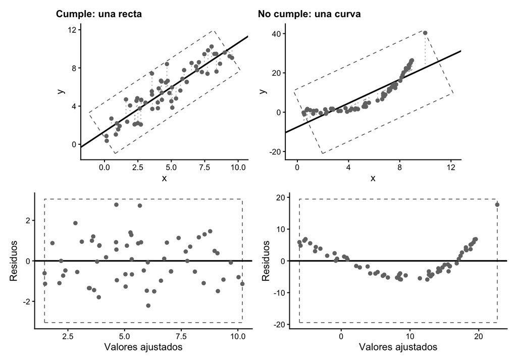

**Nota**

“Lineal” se refiere a la **combinación lineal** de los predictores: la media de $y$ es una suma de términos, cada uno un predictor multiplicado por su coeficiente, como en $\alpha + \beta_1 x_1 + \beta_2 x_2$. Lo que tiene que ser lineal son los coeficientes, no los predictores. Por eso este modelo sigue siendo lineal aunque la curva ajustada sea una parábola:

`y ~ x + I(x^2)`

Es $\alpha + \beta_1 x + \beta_2 x^2$, y cada coeficiente multiplica a su término y se suma. La recta ajustada no siempre tiene que ser una recta.

**Verificar mediante el paquete `performance`**

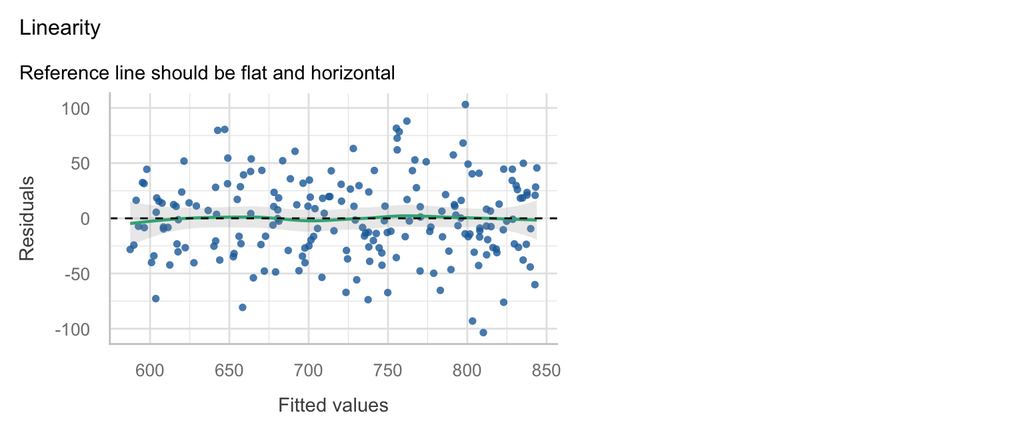

```r
plot(performance::check_model(model_sim, check = "linearity"))
```

**NotaSolución**

Añadir el predictor que falta, transformar la respuesta (logaritmo) o añadir $x^2$.

### 2. Ausencia de colinealidad

Los predictores no deben estar correlacionados entre sí.

`inteligencia ~ sílabas por segundo + palabras por segundo + frases por segundo`

> El ejemplo de Winter: queremos saber si la gente que habla más rápido parece más inteligente, y medimos la velocidad de 80 hablantes de tres maneras, en sílabas, palabras y frases por segundo. Las tres medidas dicen casi lo mismo, así que al meterlas juntas en el modelo se roban el efecto unas a otras. Aquí los datos están simulados.

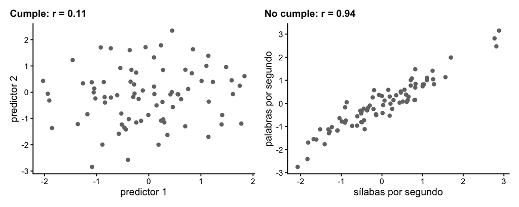

**Verificar mediante el paquete `performance`**

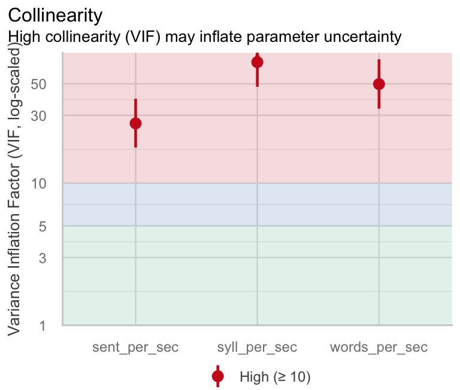

```r
plot(performance::check_collinearity(model_speech))
```

Los tres VIF pasan de 10, la zona roja del gráfico: las tres medidas dicen casi lo mismo. Con predictores que no se solapan, los puntos quedarían en la zona verde, cerca de 1.

**NotaSolución**

Quedarse con una sola medida (por teoría, no por su p-valor) o reducir dimensiones (componentes principales).

### 3. Homocedasticidad

La **homocedasticidad** (u homogeneidad de varianzas) es que la varianza de los errores se mantiene constante en todo el rango del predictor: la dispersión de los residuos es la misma para cualquier valor de $x$, o en cualquier grupo si el predictor es categórico. Lo contrario es la heterocedasticidad.

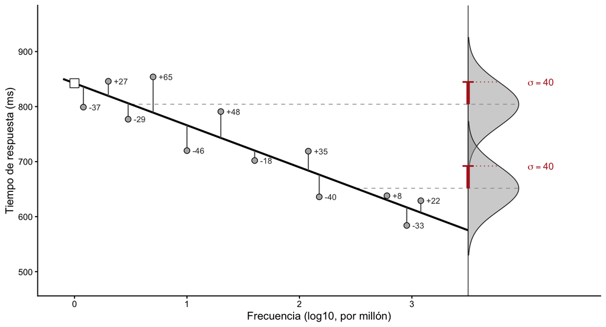

**Ejemplos:**

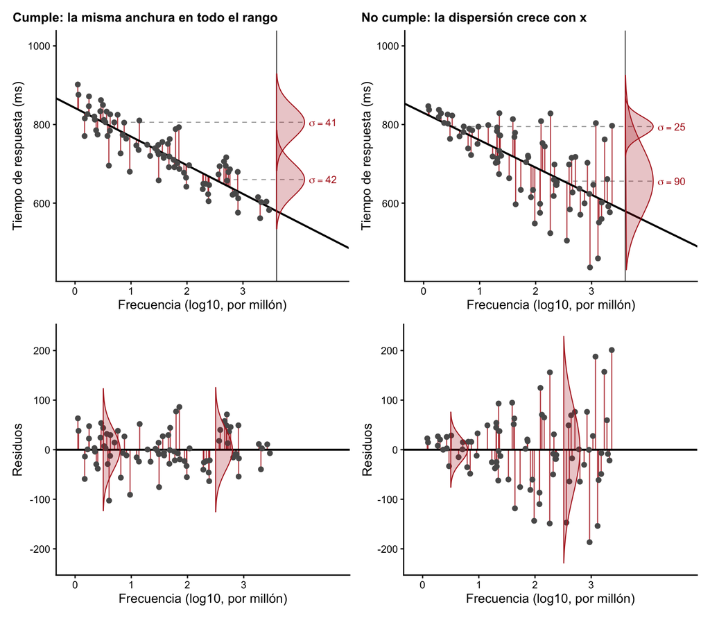

El truco de Winter para entrenar el ojo: así se ve el ruido puro. Pulsa “Otra vez” varias veces, o ejecuta el código en R.

```r
plot(x = rnorm(100), y = rnorm(100),
     xlab = "Valores ajustados", ylab = "Residuos")
abline(h = 0, lty = 2)
```

Nube número **1**

**Verificar mediante el paquete `performance`**

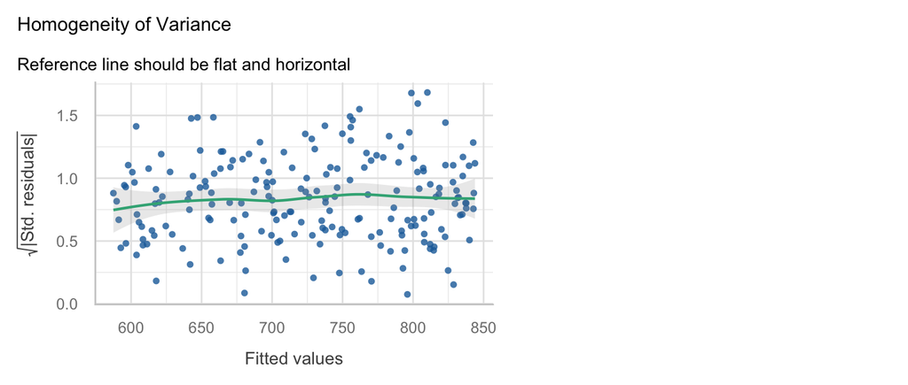

```r
plot(performance::check_model(model_sim, check = "homogeneity"))
```

**NotaSolución**

Transformar la respuesta (logaritmo).

### 4. Normalidad de los residuos

Los residuos forman una campana y, en el gráfico cuantil-cuantil, caen sobre la recta. Es el supuesto menos importante.

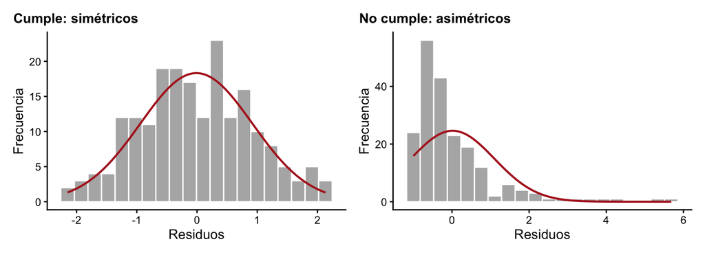

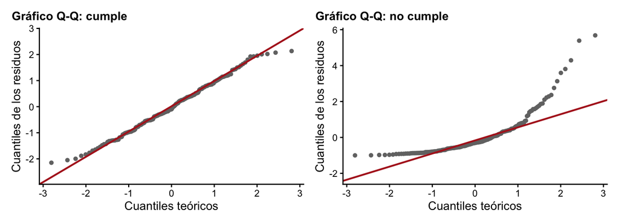

El gráfico Q-Q (cuantil-cuantil) ordena los residuos de menor a mayor y los compara con lo que se esperaría de una normal con el mismo número de datos. Cada punto es un residuo: en horizontal, el valor que ocuparía su puesto en una normal; en vertical, el valor que tiene de verdad. Si los residuos son normales, los puntos caen sobre la recta. Si se despegan por un extremo, como a la derecha, ese lado tiene una cola más larga de lo normal.

n (tamaño de la muestra):

Shapiro-Wilk: *W* = , *p* = .  
Kolmogorov-Smirnov (Lilliefors): *D* = , *p* = .

Muestras normales generadas con este *n*: . Declaradas «no normales» (*p* < 0.05): Shapiro-Wilk (), Kolmogorov-Smirnov ().

Compruébalo con datos que son normales de verdad. El generador saca $n$ valores de una normal y les pasa los dos tests clásicos, Shapiro-Wilk y Kolmogorov-Smirnov. Elige $n$ y pulsa “Otra vez” varias veces: una de cada veinte muestras normales sale “no normal”. Es el 5 % de falsos positivos que el test se permite, con cualquier $n$. Con $n$ pequeño, además, el histograma parece cualquier cosa.

Shapiro-Wilk está en R base, `shapiro.test(x)`. Kolmogorov-Smirnov con la corrección de Lilliefors, `nortest::lillie.test(x)`, es lo que da SPSS.

**Verificar mediante el paquete `performance`**

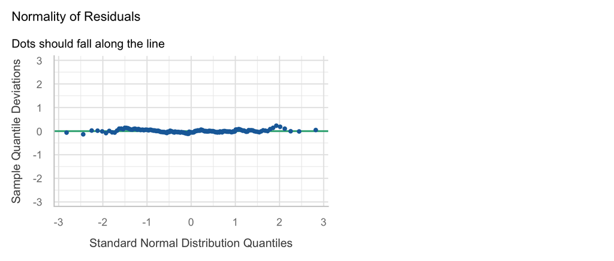

```r
plot(performance::check_model(model_sim, check = "qq"))
```

**NotaSolución**

Una desviación leve no importa, el modelo es robusto (Gelman y Hill, 2007; Schielzeth et al., 2020). Si es clara (asimetría fuerte, colas largas), transformar la respuesta (el logaritmo, habitual en tiempos de respuesta).

### 5. Ausencia de puntos influyentes

Ningún dato debe decidir él solo la recta. A la derecha, un único punto tira de la pendiente: la línea continua es la recta con él, la discontinua sin él.

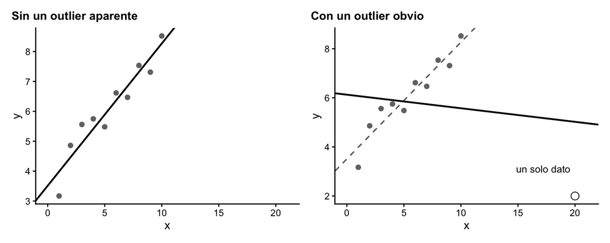

**Verificar mediante el paquete `performance`**

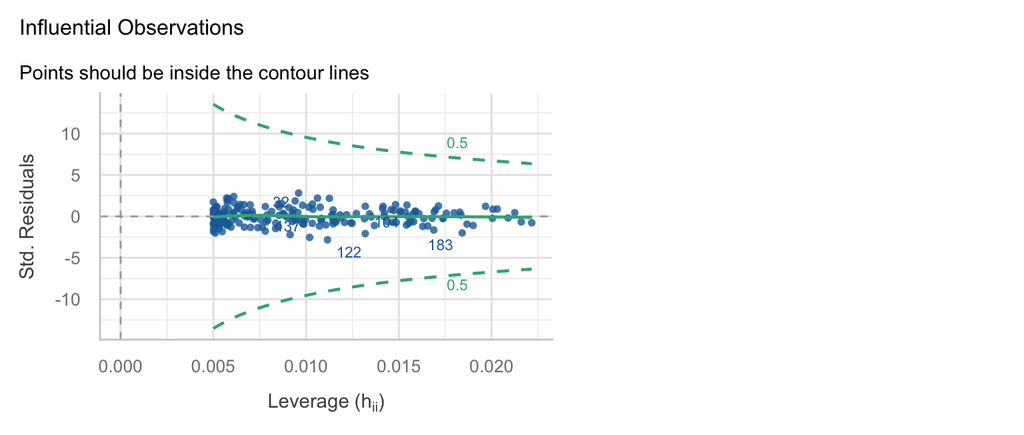

```r
plot(performance::check_model(model_sim, check = "outliers"))
```

`dfbeta()` da cuánto cambia cada coeficiente si se quita cada dato. Alarma si cambia el signo de la pendiente o llega a la mitad de su valor (la regla de Winter).

Con las 200 palabras simuladas no hay nada que señalar. Añadimos una palabra inventada para que sea influyente: muy frecuente (log10 = 4, fuera del rango de las demás) y muy lenta (950 ms).

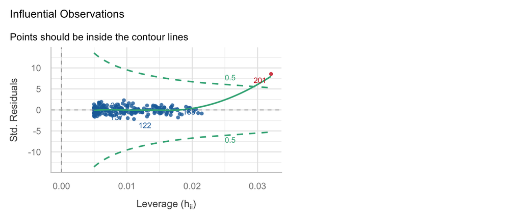

```r
plot(performance::check_model(model_out, check = "outliers"))
```

La palabra 201 sale en rojo, fuera de la línea de Cook. Con ella la pendiente pasa de -73.9 a -69.4.

**NotaSolución**

Analizar con y sin el dato, reportar los dos. Excluirlo solo si es un error (una edad negativa, un tono de 0 Hz).

### 6. Independencia

Cada dato es independiente de los demás. Es el supuesto más importante y no se comprueba con un gráfico: **se decide en el diseño**. La pregunta es cuántas medidas aporta cada persona (o camada, o ítem).

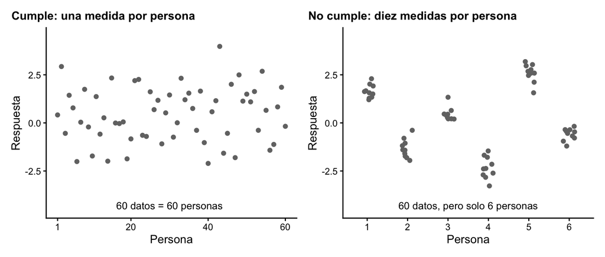

A la derecha, las medidas de una misma persona se parecen entre sí: no son 60 datos independientes, son 6 personas. Tratarlas como 60 es la **pseudorreplicación** (Hurlbert, 1984; Freeberg y Lucas, 2009; Lazic, 2010; Winter, 2011).

**NotaSolución**

Agregar o promediar los datos, o decirle al modelo que los datos no son independientes, que es lo que hacemos con los modelos lineales mixtos.

### Todo de una vez: `check_model()`

`performance::check_model()` dibuja las comprobaciones juntas y escribe en cada panel qué debería verse. La usaremos con los modelos mixtos.

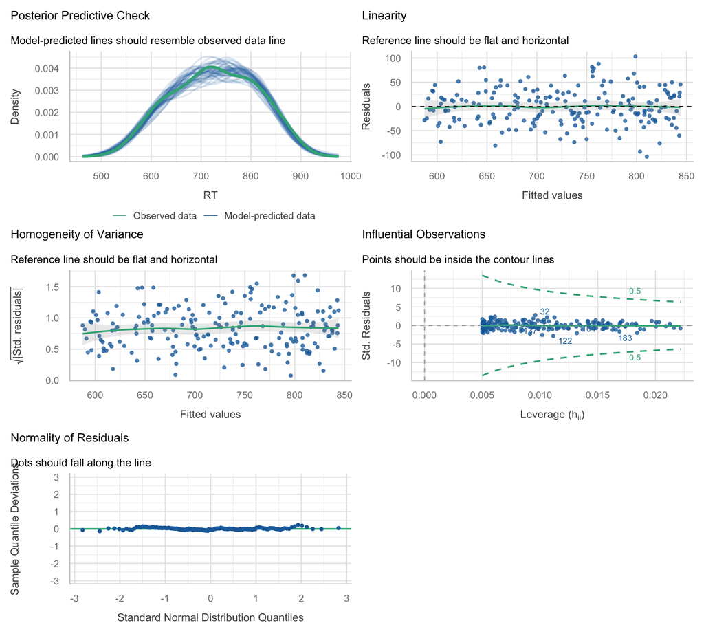

```r
performance::check_model(model_sim)
```

El primer panel, la comprobación predictiva (`check = "pp_check"`), no está en Winter: el modelo simula datos nuevos y los compara con los nuestros. Si el modelo es razonable, se parecen. La colinealidad aparece como panel en cuanto hay dos predictores; la independencia no tiene panel, se decide en el diseño.

# Referencias

Freeberg, T. M., & Lucas, J. R. (2009). Pseudoreplication is (still) a problem. *Journal of Comparative Psychology, 123*(4), 450–451. https://doi.org/10.1037/a0017031

Gelman, A., & Hill, J. (2007). *Data analysis using regression and multilevel/hierarchical models*. Cambridge University Press.

Hurlbert, S. H. (1984). Pseudoreplication and the design of ecological field experiments. *Ecological Monographs, 54*(2), 187–211. https://doi.org/10.2307/1942661

Lazic, S. E. (2010). The problem of pseudoreplication in neuroscientific studies: Is it affecting your analysis? *BMC Neuroscience, 11*, 5. https://doi.org/10.1186/1471-2202-11-5

Schielzeth, H., Dingemanse, N. J., Nakagawa, S., Westneat, D. F., Allegue, H., Teplitsky, C., Réale, D., Dochtermann, N. A., Garamszegi, L. Z., & Araya-Ajoy, Y. G. (2020). Robustness of linear mixed-effects models to violations of distributional assumptions. *Methods in Ecology and Evolution, 11*(9), 1141–1152. https://doi.org/10.1111/2041-210X.13434

Winter, B. (2011). Pseudoreplication in phonetic research. In *Proceedings of the 17th International Congress of Phonetic Sciences* (pp. 2137–2140). Hong Kong.

Winter, B. (2013). *Linear models and linear mixed effects models in R with linguistic applications*. arXiv:1308.5499. https://arxiv.org/abs/1308.5499

# Session information

**Código**